# Examining the Relationship of Rated Turbine Capacity based on Physical Specificities and Location of Canadian Wind Turbines

Rohan Bajaj

12/20/2020

# Introduction

This dataset contains information about wind turbines operating currently in Canada. My question towards making this model is if physical measurements of turbine characteristics and location makes a difference in the electric capacity of a Canadian wind turbine. I plan to use the variable, turbine_rated_capacity_k_w, as my outcome variable. My predictor variables will include rotor_diameter_m, hub_height_m, province_territory, and longitude. Designers can determine optimal heights and rotor diameter of the wind turbines to be constructed based on the location that the wind farm will be located. Alongside the physical location of a windmill, it is possible to be able to better see the energy needs of a region based on where windmills are located and how much energy they are able to provide. Perhaps this would lead to the greater specialization of wind turbines around the world to most efficiently utilize wind energy and convert it into usable electricity.

Two of my biggest concerns in regard to possible statistical problems arising from this dataset is the lack of specification of elevation that turbines were constructed on. This could possible lead to bias where a lower/higher elevation causes turbines to have a higher capacity since air is thinner as elevation increases. The bias from this could possible be recognized as the project names and farm names of these turbines are in the dataset. Values would have similar bias based on if they share the same farm or project, as the additional factor of elevation would be held relatively constant when focusing on specific physical area. My other concern is that energy needs of regions is not documented. This could very well mean that the model fitted could be vastly altered simply due to some regions of Canada having higher/lower energy needs and therefore leading windmills to be more or less populous in that area. This would also lead to the validity of the model to be in question as such a concern leads to the question regarding the influence of population energy demands upon the specifications of wind turbine construction.

# Initial Impressions of Data and Simple Regression

```r
wind_turbine <- readr::read_csv('https://raw.githubusercontent.com/rfordatascience/tidytuesday/master/data/2020/2020-10-27/wind-turbine.csv')
skim(wind_turbine)
```

Data summary

| Name | wind_turbine |
| --- | --- |
| Number of rows | 6698 |
| Number of columns | 15 |
| _______________________ |  |
| Column type frequency: |  |
| character | 8 |
| numeric | 7 |
| ________________________ |  |
| Group variables | None |

**Variable type: character**

| skim_variable | n_missing | complete_rate | min | max | empty | n_unique | whitespace |
| --- | --- | --- | --- | --- | --- | --- | --- |
| province_territory | 0 | 1.00 | 5 | 25 | 0 | 12 | 0 |
| project_name | 1 | 1.00 | 5 | 41 | 0 | 268 | 0 |
| turbine_identifier | 0 | 1.00 | 4 | 6 | 0 | 6683 | 0 |
| turbine_number_in_project | 0 | 1.00 | 3 | 7 | 0 | 4300 | 0 |
| manufacturer | 0 | 1.00 | 2 | 24 | 0 | 23 | 0 |
| model | 0 | 1.00 | 3 | 12 | 0 | 92 | 0 |
| commissioning_date | 0 | 1.00 | 4 | 14 | 0 | 35 | 0 |
| notes | 6064 | 0.09 | 20 | 196 | 0 | 27 | 0 |

**Variable type: numeric**

| skim_variable | n_missing | complete_rate | mean | sd | p0 | p25 | p50 | p75 | p100 | hist |
| --- | --- | --- | --- | --- | --- | --- | --- | --- | --- | --- |
| objectid | 0 | 1.00 | 3349.50 | 1933.69 | 1.00 | 1675.25 | 3349.50 | 5023.75 | 6698.00 | ▇▇▇▇▇ |
| total_project_capacity_mw | 0 | 1.00 | 134.76 | 90.50 | 0.30 | 70.50 | 102.00 | 181.50 | 350.00 | ▆▇▅▂▂ |
| turbine_rated_capacity_k_w | 220 | 0.97 | 1967.31 | 605.93 | 65.00 | 1600.00 | 1880.00 | 2300.00 | 3750.00 | ▁▃▇▅▁ |
| rotor_diameter_m | 0 | 1.00 | 88.62 | 16.45 | 15.00 | 80.00 | 90.00 | 100.00 | 141.00 | ▁▁▇▇▁ |
| hub_height_m | 0 | 1.00 | 83.34 | 14.44 | 24.50 | 80.00 | 80.00 | 92.00 | 132.00 | ▁▂▇▃▁ |
| latitude | 0 | 1.00 | 46.76 | 3.27 | 42.00 | 43.98 | 46.67 | 49.17 | 64.49 | ▇▇▁▁▁ |
| longitude | 0 | 1.00 | -83.03 | 17.59 | -135.23 | -84.41 | -80.67 | -67.85 | -52.97 | ▁▂▁▇▅ |

After using the skim function to intially explore my data set, I noticed that there is a proportion of my outcomes variable, the rated turbine capacity, with missing values.

```r
turbines <- wind_turbine %>%
  filter(!is.na(turbine_rated_capacity_k_w))
nrow(turbines)
```

```
## [1] 6478
```

The dataset is still sufficiently large, no concerns arise from omitting the 220 rows with the missing value in turbine_rated_capacity_k_w, so I will continue using this altered dataset as my sample set.

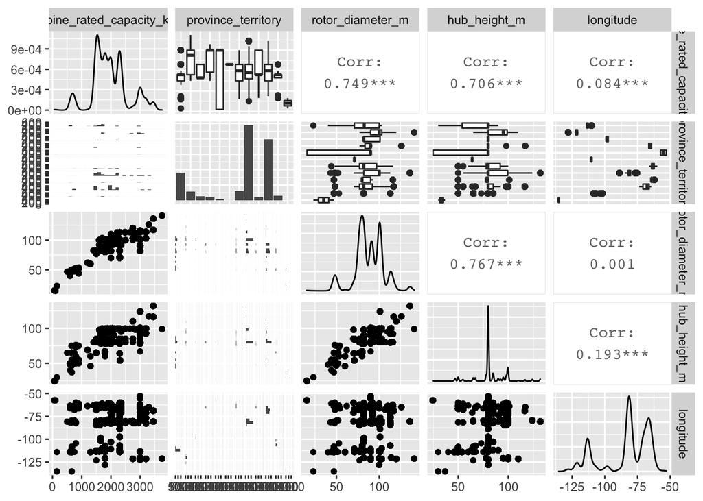

```r
turbines %>% select(turbine_rated_capacity_k_w, province_territory, rotor_diameter_m, hub_height_m, longitude) %>% ggpairs(progress = FALSE)
```

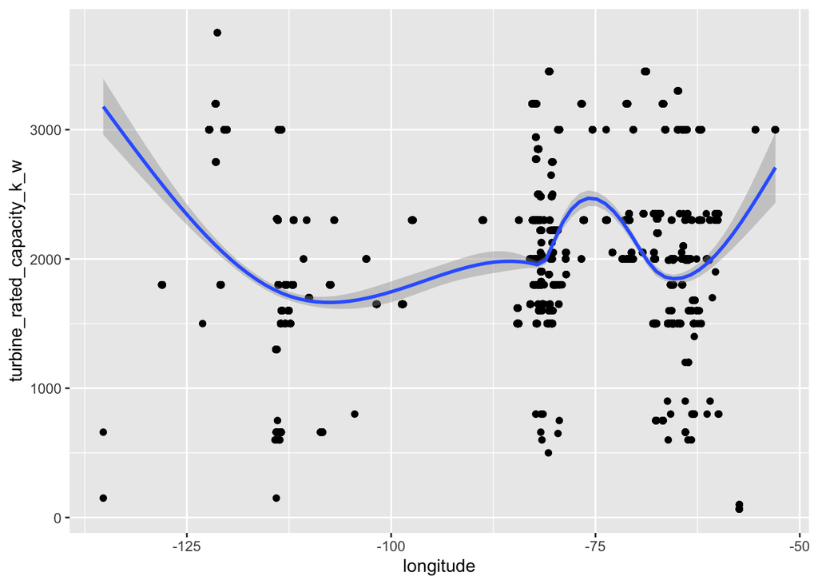

```r
ggplot(turbines, aes(x=longitude, y=turbine_rated_capacity_k_w)) + geom_point() + geom_smooth()
```

Initially looking at scatterplot of the relationship of rated capacity and exact longitude, the correlation appears extremely low, representing that such a model does not explain even 10% of the data. Taking a look at how location and capacity change on a more micro level might make different conclusions arise. A look at the ggpairs() function makes the relationship between rated capacity and longitude to not present a very clear correlation as the scatterplot doesn’t appear to follow some kind of relationship. Perhaps taking a look at hub height and rotor diameter will be a better outlook. A linear relationship is significantly more visible between turbine capacity and these two variables individually.

```r
skim(turbines)
```

Data summary

| Name | turbines |
| --- | --- |
| Number of rows | 6478 |
| Number of columns | 15 |
| _______________________ |  |
| Column type frequency: |  |
| character | 8 |
| numeric | 7 |
| ________________________ |  |
| Group variables | None |

**Variable type: character**

| skim_variable | n_missing | complete_rate | min | max | empty | n_unique | whitespace |
| --- | --- | --- | --- | --- | --- | --- | --- |
| province_territory | 0 | 1.00 | 5 | 25 | 0 | 12 | 0 |
| project_name | 1 | 1.00 | 5 | 41 | 0 | 265 | 0 |
| turbine_identifier | 0 | 1.00 | 4 | 6 | 0 | 6478 | 0 |
| turbine_number_in_project | 0 | 1.00 | 3 | 7 | 0 | 4085 | 0 |
| manufacturer | 0 | 1.00 | 2 | 24 | 0 | 23 | 0 |
| model | 0 | 1.00 | 3 | 12 | 0 | 92 | 0 |
| commissioning_date | 0 | 1.00 | 4 | 14 | 0 | 35 | 0 |
| notes | 6064 | 0.06 | 20 | 196 | 0 | 24 | 0 |

**Variable type: numeric**

| skim_variable | n_missing | complete_rate | mean | sd | p0 | p25 | p50 | p75 | p100 | hist |
| --- | --- | --- | --- | --- | --- | --- | --- | --- | --- | --- |
| objectid | 0 | 1 | 3345.41 | 1966.09 | 1.00 | 1620.25 | 3239.50 | 5078.75 | 6698.00 | ▇▇▇▇▇ |
| total_project_capacity_mw | 0 | 1 | 131.63 | 89.82 | 0.30 | 69.00 | 101.20 | 179.00 | 350.00 | ▆▇▅▂▂ |
| turbine_rated_capacity_k_w | 0 | 1 | 1967.31 | 605.93 | 65.00 | 1600.00 | 1880.00 | 2300.00 | 3750.00 | ▁▃▇▅▁ |
| rotor_diameter_m | 0 | 1 | 88.20 | 16.57 | 15.00 | 77.00 | 90.00 | 100.00 | 141.00 | ▁▁▇▆▁ |
| hub_height_m | 0 | 1 | 82.79 | 14.37 | 24.50 | 80.00 | 80.00 | 85.00 | 132.00 | ▁▂▇▂▁ |
| latitude | 0 | 1 | 46.89 | 3.25 | 42.00 | 44.04 | 47.23 | 49.18 | 64.49 | ▇▇▁▁▁ |
| longitude | 0 | 1 | -83.07 | 17.89 | -135.23 | -84.49 | -80.56 | -67.81 | -52.97 | ▁▃▁▇▅ |

```r
turbines %>% count(province_territory, sort = TRUE) ## To  see where the most wind turbines are in Canada
```

```
## # A tibble: 12 x 2
##    province_territory            n
##    <chr>                     <int>
##  1 Ontario                    2443
##  2 Quebec                     1991
##  3 Alberta                     900
##  4 Nova Scotia                 310
##  5 British Columbia            292
##  6 Saskatchewan                153
##  7 Manitoba                    133
##  8 New Brunswick               119
##  9 Prince Edward Island        104
## 10 Newfoundland and Labrador    27
## 11 Northwest Territories         4
## 12 Yukon                         2
```

Population information provided from: https://en.wikipedia.org/wiki/Population_of_Canada_by_province_and_territory

```r
turbines_provinceQOA <- sqldf( 'SELECT * FROM turbines WHERE province_territory == "Quebec" OR province_territory == "Ontario" OR province_territory == "Alberta"')
nrow(turbines_provinceQOA)
```

```
## [1] 5334
```

```r
## Proprortion of sample set to whole data set
5334/6698
```

```
## [1] 0.7963571
```

Our sample set is still relatively large after selecting values only from these provinces. It also does not drastically reduce the proportion of the sample to the whole dataset. We are using about 79.6% of the provided data moving forward in the models created.

```r
massa <- lm(turbine_rated_capacity_k_w ~ longitude, data=turbines_provinceQOA)

summary(massa)
```

```
##
## Call:
## lm(formula = turbine_rated_capacity_k_w ~ longitude, data = turbines_provinceQOA)
##
## Residuals:
##      Min       1Q   Median       3Q      Max
## -1579.75  -337.48    -8.94   297.37  1507.06
##
## Coefficients:
##              Estimate Std. Error t value Pr(>|t|)
## (Intercept) 2459.0064    42.4437   57.94   <2e-16 ***
## longitude      6.3939     0.5094   12.55   <2e-16 ***
## ---
## Signif. codes:  0 '***' 0.001 '**' 0.01 '*' 0.05 '.' 0.1 ' ' 1
##
## Residual standard error: 573.1 on 5332 degrees of freedom
## Multiple R-squared:  0.0287, Adjusted R-squared:  0.02851
## F-statistic: 157.5 on 1 and 5332 DF,  p-value: < 2.2e-16
```

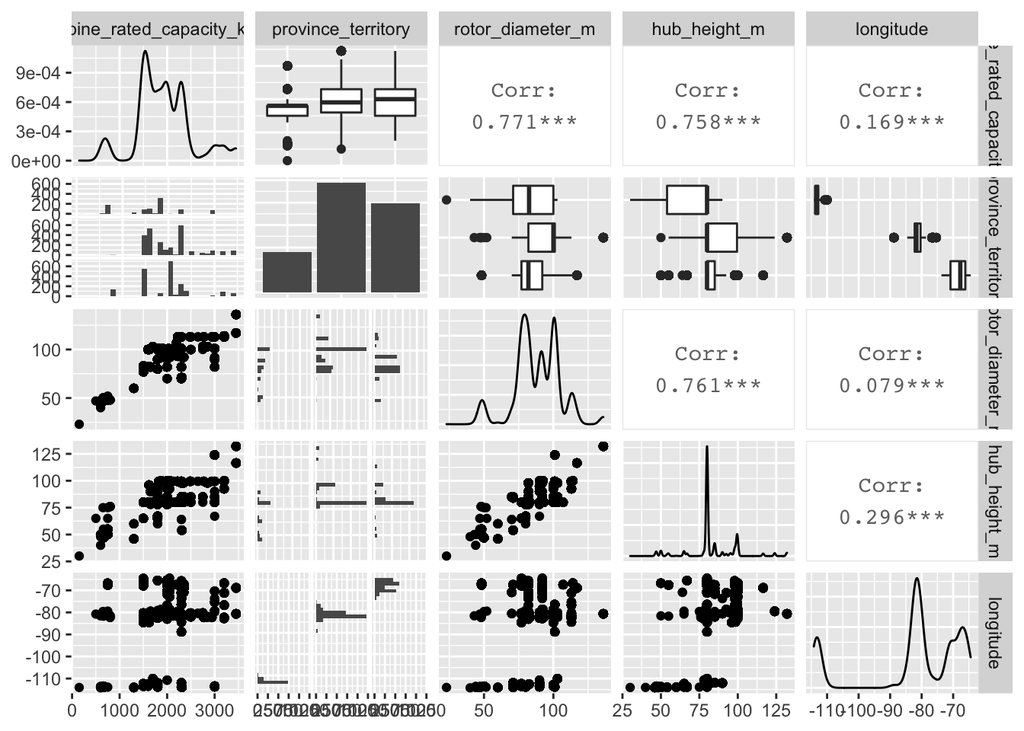

```r
turbines_provinceQOA %>% select(turbine_rated_capacity_k_w, province_territory, rotor_diameter_m, hub_height_m, longitude) %>% ggpairs(progress = FALSE)
```

By limiting our location range, longitude appears to explain a little more of the data. In fact, the distribution of values on the scatterplot showing the relationship between capacity and longitude seems to be very extreme on each side rather than randomly and evenly fitting throughout the distribution. It is not significant enough to conclude that their is not other influencers still at hand in the capacity of wind turbines in Canada. Rotor diameter and hub height continue to exhibit a possible much stronger correlations with turbine rated capacity from the shape of the scatterplot and the calculated correlations of .771 and .758 respectively.

# Multiple Regression

Taking in what we had observed from the ggpairs function, I am now going to create a multiple regression model taking in province/territory, rotor diameter, hub height, and longitude. This is since the correlation between rotor diameter, hub height with turbine capacity was decently strong. Adding this to the regression of longitude and taking into consideration of energy requirements from the province value should be able to create a better estimator of rated turbine capacity.

```r
Turbines_QOA <- lm(turbine_rated_capacity_k_w ~ province_territory + rotor_diameter_m + hub_height_m + longitude, data=turbines_provinceQOA)
summary(Turbines_QOA)
```

```
##
## Call:
## lm(formula = turbine_rated_capacity_k_w ~ province_territory +
##     rotor_diameter_m + hub_height_m + longitude, data = turbines_provinceQOA)
##
## Residuals:
##     Min      1Q  Median      3Q     Max
## -692.90 -218.59  -36.55  193.91 1206.23
##
## Coefficients:
##                             Estimate Std. Error t value Pr(>|t|)
## (Intercept)               -3635.5253   249.9616 -14.544  < 2e-16 ***
## province_territoryOntario   535.3105    70.8907   7.551 5.04e-14 ***
## province_territoryQuebec   1079.3929    99.1415  10.887  < 2e-16 ***
## rotor_diameter_m             19.1184     0.4330  44.153  < 2e-16 ***
## hub_height_m                 16.0074     0.4898  32.682  < 2e-16 ***
## longitude                   -23.2310     2.1966 -10.576  < 2e-16 ***
## ---
## Signif. codes:  0 '***' 0.001 '**' 0.01 '*' 0.05 '.' 0.1 ' ' 1
##
## Residual standard error: 317.1 on 5328 degrees of freedom
## Multiple R-squared:  0.7028, Adjusted R-squared:  0.7025
## F-statistic:  2520 on 5 and 5328 DF,  p-value: < 2.2e-16
```

The R-Squared here is not as high as expected with a dataset that considers mostly non-biological factors(other than the assumption drawn regarding population energy demands from seeing the distribution of wind turbines provided from the variable province_territory). Since the sample size is still fairly large at 5334, the adjusted R-squared does not vary greatly from R-Squared even if we are using only a few predictor variables. We don’t suffer from overfitting very much due to the adjusted R-squared being near identical to the multiple R-squared. Just out of curiosity, lets run the same model on the dataset that contains all complete rows for the variables at hand. What we do notice here is statistical significance from our p-values for the rotor_diameter_m, hub_height_m, and longitude intercepts. Such would mean that the relationship between turbine capacity and each individual variable while other held constant is statistically significant. The p-value of the model also resembles statistical significance, alluding that the relationship between these predictor variables and our outcome is also statistically significant.

```r
Turbines_ALL <- lm(turbine_rated_capacity_k_w ~ province_territory + rotor_diameter_m + hub_height_m + longitude, data=turbines)
summary(Turbines_ALL)
```

```
##
## Call:
## lm(formula = turbine_rated_capacity_k_w ~ province_territory +
##     rotor_diameter_m + hub_height_m + longitude, data = turbines)
##
## Residuals:
##     Min      1Q  Median      3Q     Max
## -866.20 -251.34  -24.96  204.56 1187.50
##
## Coefficients:
##                                               Estimate Std. Error t value
## (Intercept)                                 -2118.2175   252.6809  -8.383
## province_territoryBritish Columbia             67.9006    32.1852   2.110
## province_territoryManitoba                     92.9229    46.3757   2.004
## province_territoryNew Brunswick              1131.6235   110.9683  10.198
## province_territoryNewfoundland and Labrador  1387.1546   144.8308   9.578
## province_territoryNorthwest Territories       954.1995   173.9057   5.487
## province_territoryNova Scotia                 543.2139   112.1019   4.846
## province_territoryOntario                     129.0342    71.3359   1.809
## province_territoryPrince Edward Island        722.2947   114.6076   6.302
## province_territoryQuebec                      508.3235    99.7445   5.096
## province_territorySaskatchewan                119.7755    33.4478   3.581
## province_territoryYukon                       -21.0560   250.6067  -0.084
## rotor_diameter_m                               20.7190     0.4317  47.996
## hub_height_m                                   13.8739     0.5060  27.418
## longitude                                     -10.0150     2.2123  -4.527
##                                             Pr(>|t|)
## (Intercept)                                  < 2e-16 ***
## province_territoryBritish Columbia          0.034924 *
## province_territoryManitoba                  0.045144 *
## province_territoryNew Brunswick              < 2e-16 ***
## province_territoryNewfoundland and Labrador  < 2e-16 ***
## province_territoryNorthwest Territories     4.25e-08 ***
## province_territoryNova Scotia               1.29e-06 ***
## province_territoryOntario                   0.070524 .
## province_territoryPrince Edward Island      3.13e-10 ***
## province_territoryQuebec                    3.56e-07 ***
## province_territorySaskatchewan              0.000345 ***
## province_territoryYukon                     0.933043
## rotor_diameter_m                             < 2e-16 ***
## hub_height_m                                 < 2e-16 ***
## longitude                                   6.09e-06 ***
## ---
## Signif. codes:  0 '***' 0.001 '**' 0.01 '*' 0.05 '.' 0.1 ' ' 1
##
## Residual standard error: 346.8 on 6463 degrees of freedom
## Multiple R-squared:  0.6732, Adjusted R-squared:  0.6725
## F-statistic: 950.8 on 14 and 6463 DF,  p-value: < 2.2e-16
```

It appears that limiting our dataset to the most populous provinces led us to go a little astray in seeing the relationship between capacity, rotor diameter, hub height, and location. Taking in all of Canada’s documented wind turbines in the dataset with non-null rated capacities, our R-Squared output lower at .6732. Could this mean that certain locations have abnormally large/small turbine capacities? This difference is not alarming when continuing our model. The R-Squared, Adjusted and Multiple, does not change extrememly when taking in this entire data set. Our filtered data set does also have a sufficiently, row-wise and proportionally, large data set.

Let’s take a look at the diagnostic plot of our filtered province set.

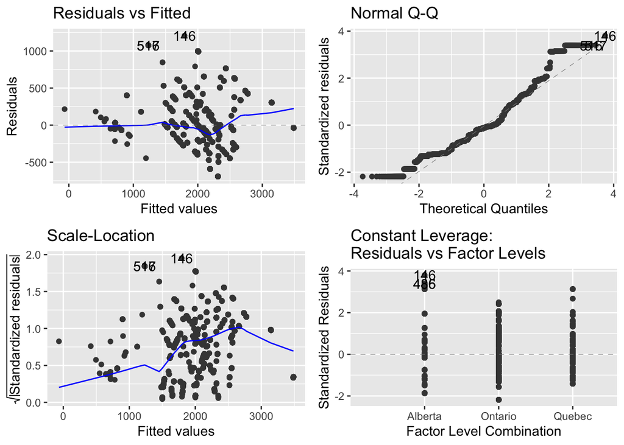

```r
autoplot(Turbines_QOA)
```

Issues seen:

- The residuals vs Fitted and Scale-Location plots mark some residual outliers, specifically data points 517, 516, and 146 appear to definitely be highlighted. The plots also provide an outlook at the practical implementation of wind turbines. Most data sets lie in the middle of the range of fitted values. This would make sense as turbines ideally would not be constructed to only hold extremely small relative amounts of electricity when providing energy infrastructure across a country. Abnormally large capacity wind turbines also would be rare possibly from a lack of technological advancement that leads to more efficient and more capable turbines in Canada.
- The Scale-Location and Residual vs Fitted plots also show that the residuals are not completely randomly spread throughout the range of fitted values. Since residuals dont appear to follow a relatively consistent spread, the smooth line is not very straight in the Scale-Location plot.
- The distribution of residuals appears non-normal, marked by the Quantile-Quantile plot where the lower left end of residuals verge off the straight dotted line. The upper right end also exhibits this with a chunk of all the values being completely off the straight line and instead exhibiting stagnation rather than increasing standardized residuals with increasing theoretical quantiles.
- Leverage of standardized residuals from the Alberta province appears to be greater than from the Ontario and Quebec province. Specific data rows of 146 and 486 appear to be potentially problematic to the model from their high leverage.

Overall, our diagnostic plots bring caution towards the model and any conclusions we recieve from it since the conditions of the residuals are not effectively met.

```r
confint(Turbines_QOA)
```

```
##                                 2.5 %      97.5 %
## (Intercept)               -4125.55229 -3145.49834
## province_territoryOntario   396.33566   674.28528
## province_territoryQuebec    885.03499  1273.75078
## rotor_diameter_m             18.26955    19.96730
## hub_height_m                 15.04718    16.96755
## longitude                   -27.53730   -18.92473
```

Taking a 95% confidence interval, the rotor_diameter_m coefficient is about 19 and the hub_height_m coefficient is about 16. The model predicts 19 more kilowatts of capacity with every meter increase in the diameter of the rotor of a Canadian wind turbine and 16 more kilowatts of capacity with every meter increase of height of the hub of a Canadian wind turbine when every other predictor is held constant. This brings a practical significant result that indeed a Canadian wind turbine that increases in physical size of its attributes will indeed rise in rated electrical capacity in kilowatts. It seems very practically significant when constructing wind turbines as rather than location, which was previously seen to explain very little of the outcome, architects can place their full focus on innovating the characteristics of a turbine instead of putting large concern on the exact location of the wind turbine. To note, the coefficients of the province_territory predictor variables can provide two explanations. The elevations and wind speed of Ontario and Quebec are not very far off. In fact, should an increased wind speed lead to more electricity generation, Ontario’s coefficient should be slightly higher then Quebec’s from the wind effects of Lake Ontario, but this isn’t the case. Another assumption I am making that would explain these coefficients as a result of energy demand from their populations rather than wind turbines that have some kind of advantage in accumulating capacity simply due to their location. This would also explain why the intervals of the province_territory coefficients is so large, it is representing how many wind turbines are really built from this energy demand.

Wind Speed and Elevation Data from: https://en.wikipedia.org/wiki/Ontario and https://en.wikipedia.org/wiki/Quebec and https://www.currentresults.com/Weather/Canada/Cities/wind-annual-average.php

# Conclusions

Based on our multiple regression model, there appears to be a statistically significant association from location and turbine attributes with the rated capacity of wind turbines. Turbine Attributes are also have practically significant association with the rated capacity of wind turbines when all other variables are held constant. There are positive associations for rotor_diameter_m and hub_height_m as well as positive intercept shifts in the province_territoryOntario and province_territoryQuebec subgroups. The coefficient of longitude is not very practically significant from its previous observance to not explain an overwhelming majority of the outcome variable of turbine capacity. It’s asocation is also quite weak with turbine capacity as longitude appears to be unable to explain more than 10% of the outcome data of turbine capacity.

In creating our models, we filtered the dataset to only include turbine data from three of Canada’s four most populous provinces and territories: Quebec, Ontario, and Alberta. In doing so, we were still able to analyse about 80% of the Canadian wind turbine data provided. This is a precaution when implementing our findings, but should not be that alarming as the overall correlation between rated turbine capacity, it physical attributes, regional and specific location does not change extremely drastically when applying the model to the entire, complete dataset.

In our model diagnostic plots, a couple issues also arose. Assumptions of the residuals, such as random even distribution of residuals known as homoskedacity, were not present. Outliers also appeared to have significant leverage upon our sample set. Such occurrences might lead to our confidence interval to be misleading. Especially when taking in attributes of turbines that have very high/small rated capacities.

Implementing our findings into the real world appears to be comfortably applicable when considering solely physical measurements of a wind turbine’s rotor and hub. What the model has provided us with is the observed limited effect of location and much greater effect of design. Where wind energy is demanded, wind turbines can provide greater capacity through their design including larger rotors and and taller hubs. However, this dataset SOLELY takes turbine data from Canada. Design differences between the wind energy industries of different countries could indeed provide other variables that better relate to rated capacity. Such elements of design should not be ignored and instead considered alongside physical measurements of rotors and hubs when determining turbine capacity around the world. Without exhibition of the positive association of rotor diameter and hub height with rated capacity from turbines located in Non-Canadian regions, our findings should be applied to Canadian wind energy projects.

Technological advancement is another limitation to be considered. The turbine data encompasses wind turbines built within the last three decades. Possible technological overhaul in the future might lead to different variables of turbine construction that more prominently affect capacity.

I would recollect this data taking into consideration average wind speeds where turbines are located. Doing so can provide another predictor variable for rated capacity, as at the end of the day, the wind must blow for these things to work in the first place!

The most important thing to consider from this analysis is that our output variable was a rating instead of a real-world measure. Wind turbines in Canada may produce less/more energy based on factors such as wind speed. Such a provision where both windspeed and real-life measured capacity of turbines is provided would bring more real-world validity into the model. We will not be preidicting a result that is already a prediction, but instead a measurement provided from real-world observations.